# Master of Finance 841: Financial Technology and Innovation

## Lecture #1

### Ryan Riordan <br> Twitter: <span class="citation">@algoriordan</span> <br> Website: www.ryanriordan.ca <br> Smith School of Business at Queen’s University

### 2017/03/08 <br><br> Slides available <a href="https://dl.dropboxusercontent.com/s/lnqdcxstamijiak/Lecture1.html?dl=0">here</a> <br>

## Buy or Sell?

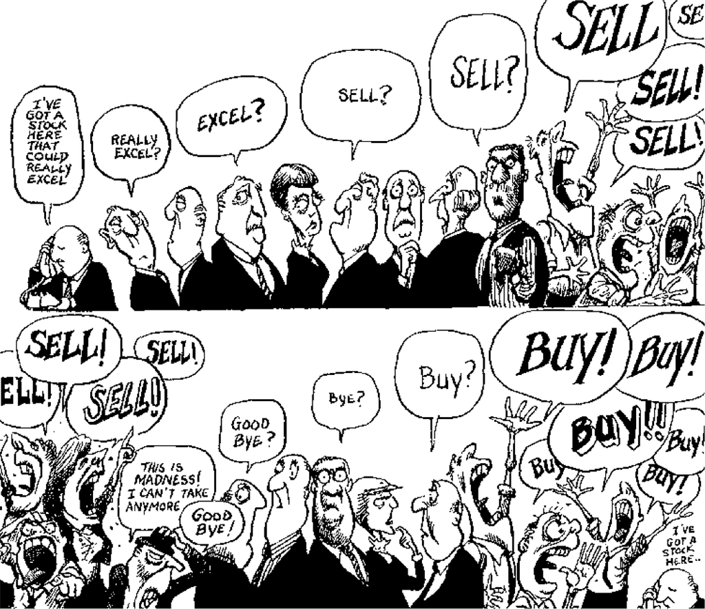

[figure not shown]

# This is the first FinTech course (beta test) in a graduate program that we know of in Canada!

## Welcome to FinTech

1. What attracted you to this course?

2. What do you hope to learn?

3. Do you have future plans involving FinTech that expand beyond this course?

4. What is your definition of FinTech?

## What is Fintech?

[video not shown]

## Goals of this course

> The purpose of this course is to examine emerging advances in all aspects of innovative financial technologies (FinTech), including:

1. How information is transmitted

2. How trading takes place today

3. New currency and payment systems

4. Humans interacting with machines

5. Borrowing and lending

6. What does the future hold?

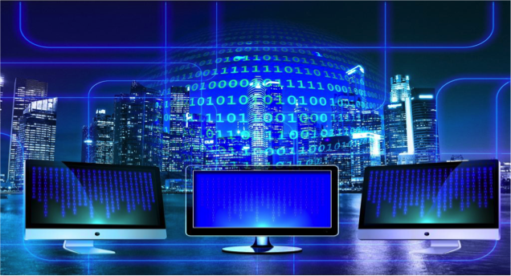

# [Course Outline](../Syllabus/MFin841_FintechOutline_Final.pdf)

## The Instructor - Dr. Ryan Riordan

**Associate Professor of Finance**
**SSB Distinguished Faculty Fellow of Finance**

*PhD Dissertation Topic:*
The Economics of Algorithmic Trading

*Academic Positions:*
* Queen’s School of Business
* University of Ontario Institute of Technology
* Karlsruhe Institute of Technology
* University of California at Berkeley (Visiting Scholar)

*Some Research Awards and Grants:*
1. The Monieson Centre for Business Research: Disruptive Technology and Financial Innovation [(Monieson Centre)](https://smith.queensu.ca/centres/monieson/disruptive_technology_financial_innovation.php)
2. Social Sciences and Humanities Research Council ($80,000)

Click here for my [CV](https://www.dropbox.com/s/dmvsukwtbwgvu8f/Ryan_Riordan_CV.pdf?dl=0).
For my research, visit my webpage: [www.ryanriordan.ca](http://www.ryanriordan.ca) or [my Google Scholar](https://scholar.google.ca/citations?user=3xgPUpkAAAAJ&hl=en) page.

## This Lecture

1. The Financial System

1. Social Media and Machine Readable News (we will skip this for now)

1. Limit Order Markets, Algorithmic, and High Frequency Trading

1. The payment system (Blockchain and Bitcoin)

1. Crowd funding, Peer-to-Peer Lending

1. Robo-Advisors

1. Artificial Intelligence

## Information and Funds Flow

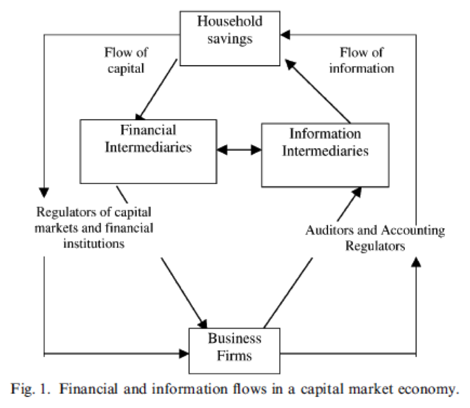

## Who are the (non-financial) actors?

1. Households

1. Business enterprises

1. Nonprofit organizations

1. Government

## The Financial System

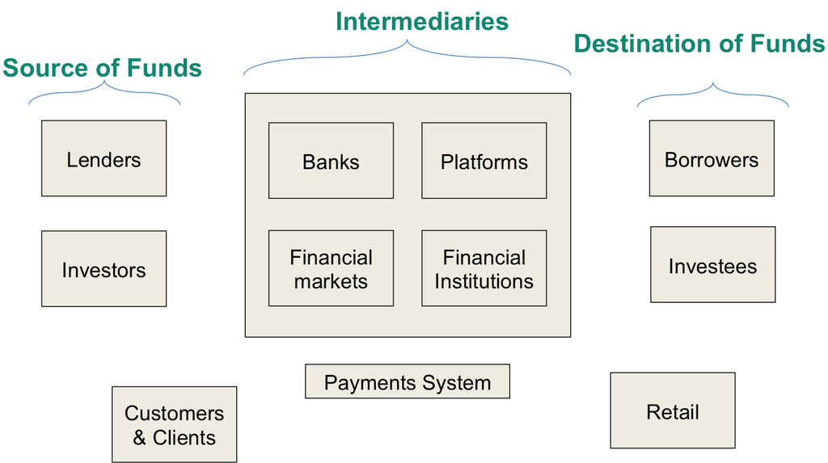

## Who are the typical financial actors (intermediaries)?

1. The banking system
 + Federal Reserve Banks
 + Commercial banks
 + Savings banks
 + Schedule I, II, and III banks (in Canada)

2. Other depository organizations
 + Savings and loan associations
 + Credit unions

## Who are the typical financial actors? Cont...

3. Insurance organizations
 + Private life insurance organizations (including fraternal and
savings bank life insurance)
 + Private non-insured pension funds
 + Government insurance and pension funds
 + Property insurance companies

4. Other financial intermediaries
 + Investment companies (including investment-holding and installment
investment companies)
 + Mortgage companies
 + Finance companies (including sales finance, personal finance and factoring companies)
 + Security brokers and dealers

## Functions performed by financial intermediaries

There are five general roles played by intermediaries. Financial intermediaries simultaneously interact with borrowers and savers and (should):

1. Facilitate transactions (in markets and between buyers and sellers of goods)
2. Support portfolio creation
3. Ease household liquidity constraints
4. Help to spread risks over time
5. Reduce the problem of asymmetric information

## Disruptions to the Financial System

1. New entities
 + Destabilize traditional links in the financial system

2. Financial technology
 + Industry comprised of technology firms focused on improving efficiency in financial system

3. New payment systems
 + Digital wallets
 + Mobile payments (e.g. Square, Inc.), Paypal, Apple Pay
 + Bitcoin

4. New intermediaries
 + Crowd-funding
 + ETFs
 + Micro-lending
 + New stock exchanges (e.g. IEX),
 + Robot financial advisors

## Agenda

1. *The Financial System*

1. **Limit Order Markets, Algorithmic, and High Frequency Trading**

1. The payment system (Blockchain and Bitcoin)

1. Crowd-funding, Peer-to-Peer Lending

1. Robo-Advisors

1. Artificial Intelligence

## Financial Markets

> "Markets are fascinating. They change constantly as prices adjust to new information, as winning traders replace losing traders, and as new technologies evolve. Highly skilled professional traders employ clever strategies in the search for trading profits. They ultimately profit from investors, gamblers, and foolish traders. The stakes in some markets are very high. Traders may arrange multimillion-dollar trades in seconds. They sometimes make or lose fortunes overnight. The prices that traders negotiate ultimately determine how market-based economies allocate their scarce resources. Free economies owe much of their wealth to their well functioning markets" <sup>1</sup>

[1] Harris, Larry. Trading and exchanges: Market microstructure for practitioners. Oxford University Press, USA, 2003.

## The Stock Market

The stock market is generally organized into trading phases:

1. Pre-opening period

1. Opening call auction

1. Continuous trading

1. Mid-day call auction

1. Pre-closing period (market on close)

1. Closing call auction

## Stylized Limit Order Book

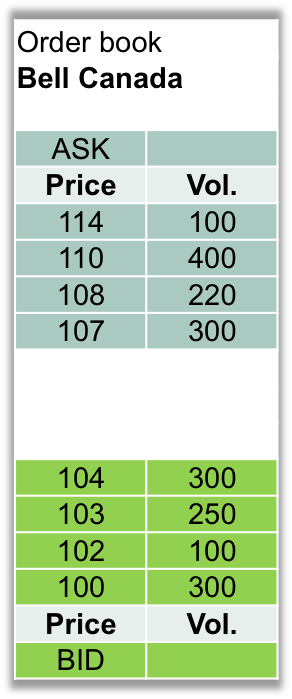

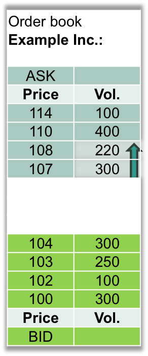

## Amazon Limit Order Book

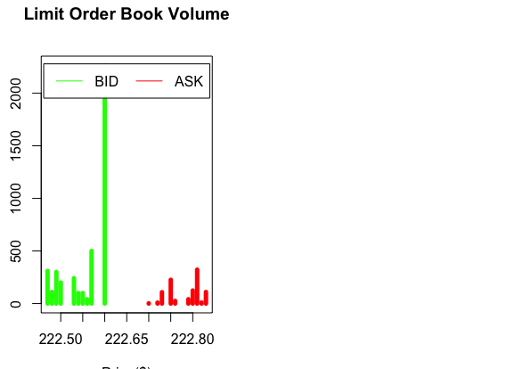

## Amazon Limit Order Book over the Day

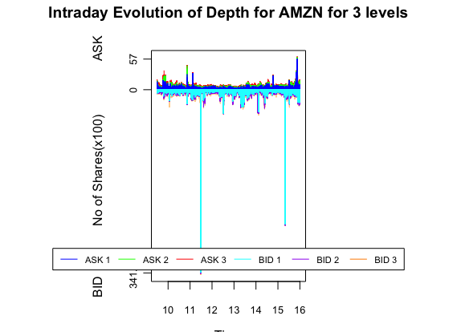

## Algorithmic Trading

> "The use of Algorithms to manage the trading process"

Institutions use algorithms for:

1. Submitting orders

1. Cancelling orders

1. Determining where to route an order (smart order routing)

1. Determining order size

1. Optimally splitting large parent orders

1. Managing execution costs

## A Taxonomy of Automated Investors

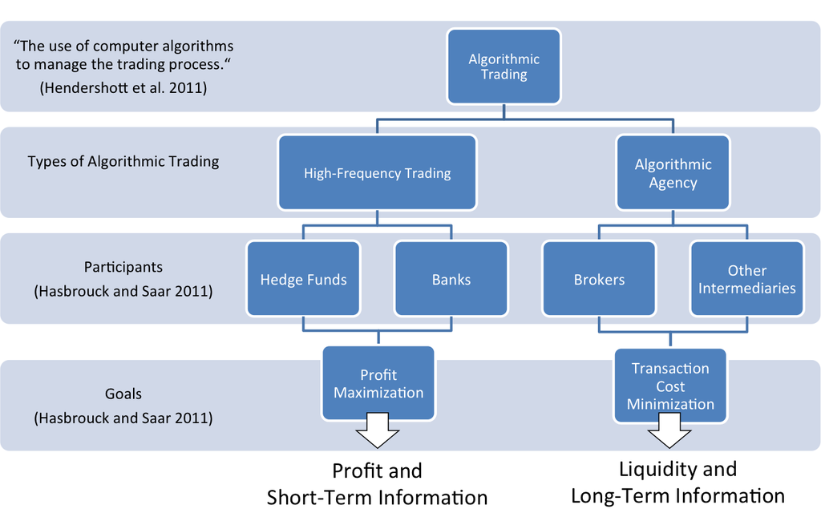

#What is High Frequency Trading?

https://modernmarketsinitiative.org/wp-content/uploads/2017/02/011317_SavesMoney_v05.mp4

## Agenda

1. *The Financial System*

1. *Limit Order Markets, Algorithmic, and High Frequency Trading*

1. **The payment system (Blockchain and Bitcoin)**

1. Crowd-funding and Peer-to-Peer Lending

1. Robo-Advisors

1. Artificial Intelligence

## The Payment System

We will cover some of the following:

1. Traditional forms of payment

1. Electronic forms of payment (Bitcoin and Cryptocurrencies)

1. Clearing and settlement systems (Central Clearinghouse)

1. Distributed ledger systems (Blockchain)

1. The Future

## Payments in Canada Today

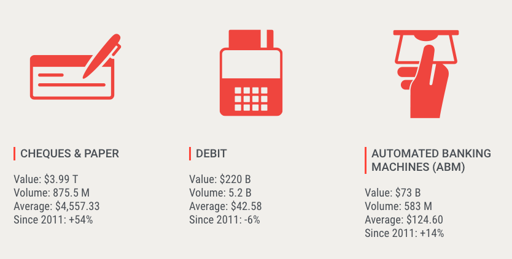

[*] See: Payments Canada Report - https://www.payments.ca/sites/default/files/cpmt_report_english_0.pdf.

## Payments in Canada Today Continued...

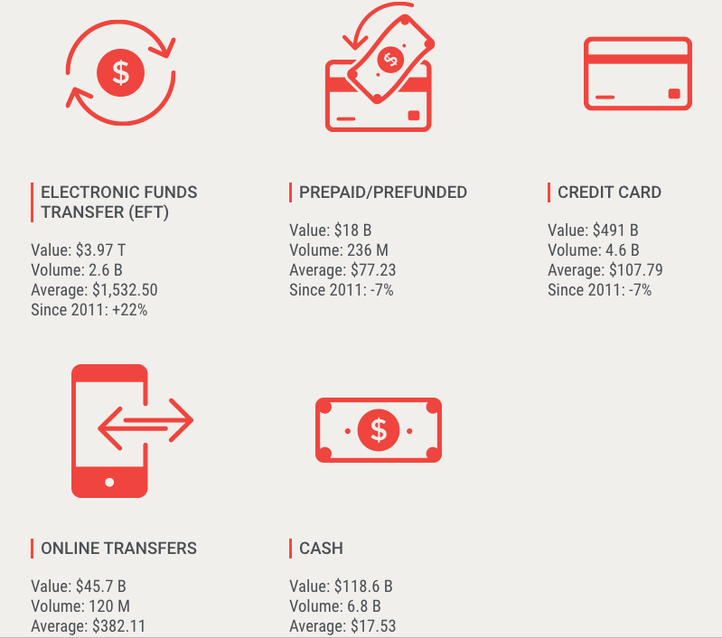

## What is a Bitcoin

[video not shown]

## Current Bitcoin Price

[output not shown]

```
##    market base quote           timestamp market_timestamp    last     vwap
## 1: kraken  BTC   EUR 2017-03-20 17:55:38             <NA> 960.544 954.6799
##      volume   ask    bid
## 1: 15169.93 961.4 960.39
```

```
##                    date   price     amount                 tid type
##  1: 2017-03-20 21:54:05 961.999 0.08285206                  NA  bid
##  2: 2017-03-20 21:54:45 962.000 0.81931292                  NA  bid
##  3: 2017-03-20 21:54:49 960.545 2.00000000                  NA  ask
##  4: 2017-03-20 21:54:49 960.545 0.12640000                  NA  ask
##  5: 2017-03-20 21:54:51 960.545 0.40216309                  NA  ask
##  6: 2017-03-20 21:54:52 960.545 0.23365009                  NA  ask
##  7: 2017-03-20 21:54:52 960.545 0.73678682                  NA  ask
##  8: 2017-03-20 21:54:52 960.545 0.97474991                  NA  ask
##  9: 2017-03-20 21:55:06 960.545 1.00000000                  NA  ask
## 10: 2017-03-20 21:55:06 960.544 3.66902962 1490046906507384130  ask
```

## Evolution of Bitcoin Price

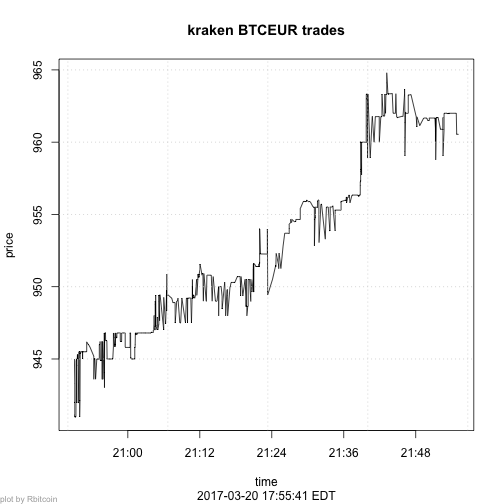

## The Blockchain

The blockchain is a distributed ledger system that manages Bitcoin transactions. Blockchain is a shared, unfalsifiable ledger for recording the history of (digital) transactions. It is open for all to see and relies on a distributed network of "verifiers" to manage its integrity.

##[Blockchain Information](https://blockchain.info/)

## Crowdfunding and Peer-to-Peer Lending

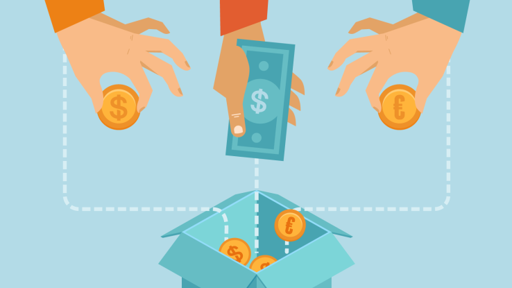

[*] See: https://techcrunch.com/2017/02/27/2017-crowdfunding-guide/

## Robo-Advisers

> "The longer answer is that a robo-advisor is a service that uses highly specialized software to do the job of wealth managers or investment advisors – people who decide what type of investments you should be making and then tinker with those investments over time. Robo-advisors typically have you, the investor, answer a few questions to determine your appetite for risk and then, through the use of proprietary algorithms, spread your money into appropriate investments, making adjustments as your situation and the market change. They typically collect around 1% less in fees than a professional investment advisor. Robo-advisors invest primarily in ETFs."
<sup>1</sup>

[*] See: https://www.wealthsimple.com/en-ca/investing-101/roboadvisor

## Investors want value for money.

[figure not shown]

[*][Economist](http://www.economist.com/news/finance-and-economics/21695552-consumers-are-finally-revolting-against-outdated-industry-tide-turns)

## How do Robo-Advisors Stack Up?

[interactive chart not shown]

## How will Robo-Advisers Hold Up During a Recession?

Passive investments may work well when markets are *increasing*. There is a saying that "a rising tide floats all boats." Robo-advisers have yet to deal with truly negative or **crashing markets**. How will they, and importantly, their clients deal with **losses**?

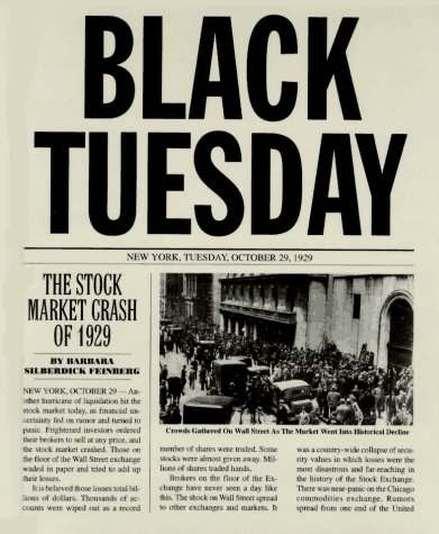

[Money Sense - Robo-advisors Plan to Survive Bear Market](http://www.moneysense.ca/news/robo-advisors-plan-survive-bear-market/)

[The Street - How Will Robo Advisors do in a Recession](https://www.thestreet.com/story/14029091/1/how-will-robo-advisors-do-in-a-recession.html)

## Agenda

1. *The Financial System*

1. *Limit Order Markets, Algorithmic, and High Frequency Trading*

1. *The payment system (Blockchain and Bitcoin)*

1. *Crowdfunding and Peer-to-Peer Lending*

1. *Robo-Advisors*

1. **Artificial Intelligence**

## Artificial Intelligence and Machine Learning

Definition of artificial intelligence:

1. a branch of computer science dealing with the simulation of intelligent behavior in computers

2. the capability of a machine to imitate intelligent human behavior

[figure not shown]

[1 - Merriam Webster Dictionary](https://www.merriam-webster.com/dictionary/artificial%20intelligence)
[2 - XKCD](HTTP://IMGS.XKCD.COM/COMICS/AI.PNG)

## Is AI used in the Financial Industry?

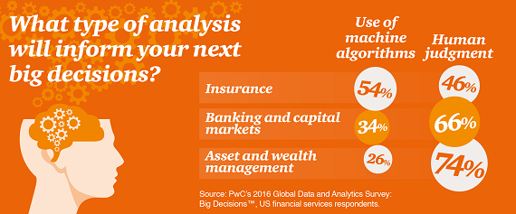

[1 - PWC](http://www.pwc.com/us/en/financial-services/research-institute/artificial-intelligence.html)

## How is this useful in Finance?

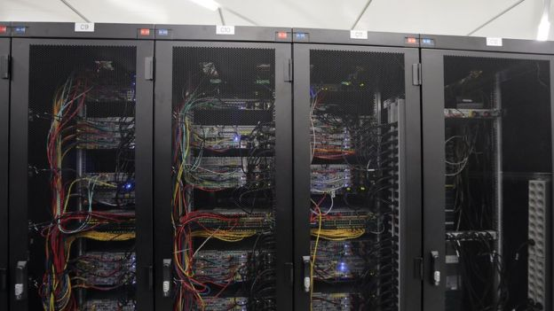

[1 - BBC](http://www.bbc.com/news/business-34264380)

## Next Steps

1. *The Financial System* - Day 1

1. Social Media and Machine Readable News - Day 1

1. *Limit Order Markets, Algorithmic, and High Frequency Trading* - Day 2

1. *The payment system (Blockchain and Bitcoin)* - Day 2

1. *Crowdfunding and Peer-to-Peer Lending* - Day 3

1. *Robo-Advisors* - Day 3

1. *Artificial Intelligence* - Day 4

1. **Final Project Presentation** - End of Day 4

#LUNCH!